# Chapter 5 - Dimensionality reduction techniques

- Part 1 - the “Human” data

We will start working by opening the data that has been wrangled before for analysis purposes. The dataset has 155 observations of 8 variables. It considers education, life expectation, labour force participation and parliamentary representation in different countries in the world.

```
## [1] 155   8
```

```
## 'data.frame':    155 obs. of  8 variables:
##  $ Edu2.FM  : num  1.007 0.997 0.983 0.989 0.969 ...
##  $ Labo.FM  : num  0.891 0.819 0.825 0.884 0.829 ...
##  $ Edu.Exp  : num  17.5 20.2 15.8 18.7 17.9 16.5 18.6 16.5 15.9 19.2 ...
##  $ Life.Exp : num  81.6 82.4 83 80.2 81.6 80.9 80.9 79.1 82 81.8 ...
##  $ GNI      : int  64992 42261 56431 44025 45435 43919 39568 52947 42155 32689 ...
##  $ Mat.Mor  : int  4 6 6 5 6 7 9 28 11 8 ...
##  $ Ado.Birth: num  7.8 12.1 1.9 5.1 6.2 3.8 8.2 31 14.5 25.3 ...
##  $ Parli.F  : num  39.6 30.5 28.5 38 36.9 36.9 19.9 19.4 28.2 31.4 ...
```

```r
library(ggplot2)
library(GGally)

summary(human)
```

```
##     Edu2.FM          Labo.FM          Edu.Exp         Life.Exp
##  Min.   :0.1717   Min.   :0.1857   Min.   : 5.40   Min.   :49.00
##  1st Qu.:0.7264   1st Qu.:0.5984   1st Qu.:11.25   1st Qu.:66.30
##  Median :0.9375   Median :0.7535   Median :13.50   Median :74.20
##  Mean   :0.8529   Mean   :0.7074   Mean   :13.18   Mean   :71.65
##  3rd Qu.:0.9968   3rd Qu.:0.8535   3rd Qu.:15.20   3rd Qu.:77.25
##  Max.   :1.4967   Max.   :1.0380   Max.   :20.20   Max.   :83.50
##       GNI            Mat.Mor         Ado.Birth         Parli.F
##  Min.   :   581   Min.   :   1.0   Min.   :  0.60   Min.   : 0.00
##  1st Qu.:  4198   1st Qu.:  11.5   1st Qu.: 12.65   1st Qu.:12.40
##  Median : 12040   Median :  49.0   Median : 33.60   Median :19.30
##  Mean   : 17628   Mean   : 149.1   Mean   : 47.16   Mean   :20.91
##  3rd Qu.: 24512   3rd Qu.: 190.0   3rd Qu.: 71.95   3rd Qu.:27.95
##  Max.   :123124   Max.   :1100.0   Max.   :204.80   Max.   :57.50
```

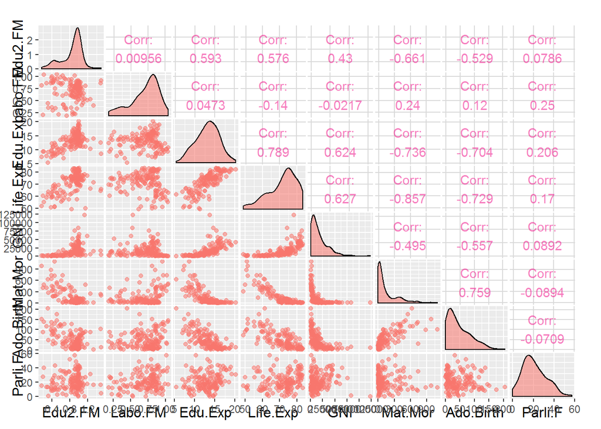

```r
p <- ggpairs(human, mapping = aes(col="deeppink2", alpha=0.3), lower = list(combo = wrap("facethist", bins = 20)))

p
```

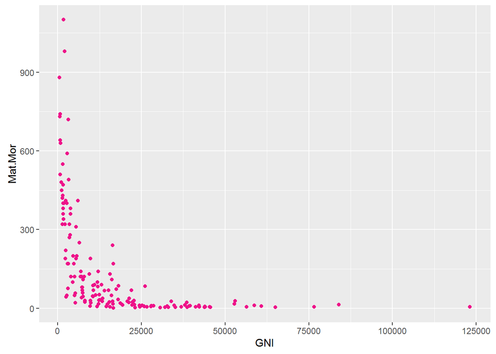

```r
p2 <- ggplot(human, aes(x=GNI, y= Mat.Mor)) + geom_point(col="deeppink2")

p2
```

The scatterplot shows that when GNI is low, the maternal mortality is much higher than with greater values of GNI. This makes sense, because maternal mortality is known to be approximately zero in any welfare state.

Next we will perform a principal component analysis.

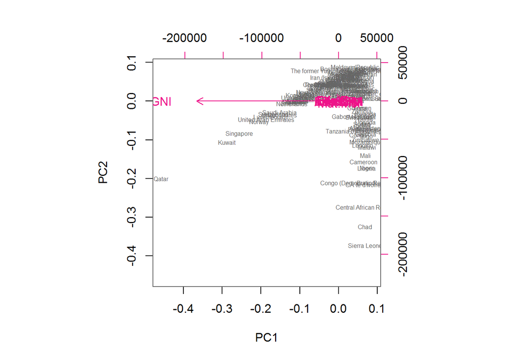

```r
pca_human <- prcomp(human)

biplot(pca_human, choices = 1:2, cex = c(0.5, 1), col = c("grey40", "deeppink2"))
```

```r
human_std <- scale(human)
```

Now we can perform the principal component analysis with the standardized ‘human’ data.

```r
# perform principal component analysis (with the SVD method)
pca_human2 <- prcomp(human_std)

summary(pca_human2)
```

```
## Importance of components:
##                           PC1    PC2     PC3     PC4     PC5     PC6
## Standard deviation     2.0708 1.1397 0.87505 0.77886 0.66196 0.53631
## Proportion of Variance 0.5361 0.1624 0.09571 0.07583 0.05477 0.03595
## Cumulative Proportion  0.5361 0.6984 0.79413 0.86996 0.92473 0.96069
##                            PC7     PC8
## Standard deviation     0.45900 0.32224
## Proportion of Variance 0.02634 0.01298
## Cumulative Proportion  0.98702 1.00000
```

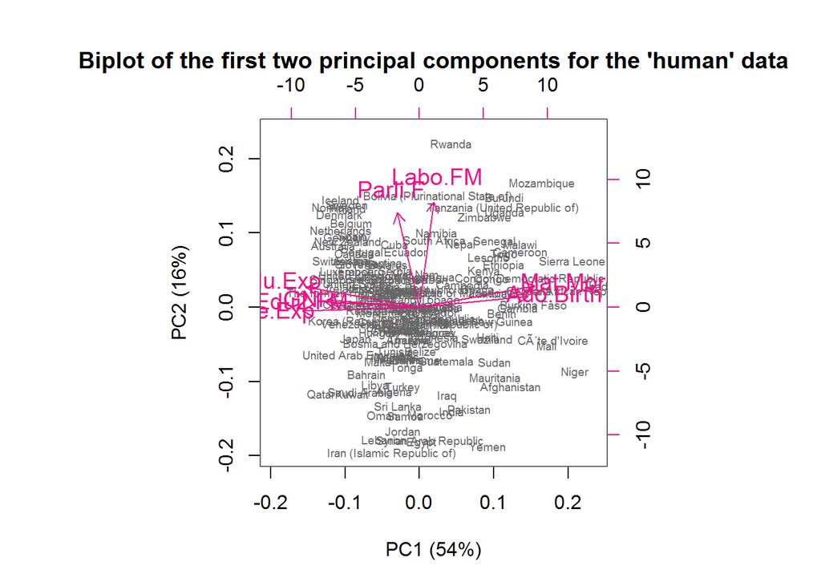

```r
biplot(pca_human2, choices = 1:2, cex = c(0.6, 1.2), col = c("grey40", "deeppink2"), main="Biplot of the first two principal components for the 'human' data", xlab="PC1 (54%)", ylab="PC2 (16%)")
```

This biplot is much more informatic, as the observations are clearer and the arrows now show the relationships between the variables in the dataset. This is due to the standardation which have made the variances of the variables more comparable. The PCA procedure assumes a feature with a large variance to be more important than one with a small variance, regardless of the scaling of features. If the data is not standardized, the comparison will probably become biased due to the non-similar scaling.

The summary of the PCA tells that PC1 has nearly 54% of the variance of the data and the second PC2 has just 16%. Together they have around 70% of the variance of the features, so there is a good reason to use only these first two PC’s in the biplot and analysis.

- Part 2 - the “tea” data from package FactoMineR

Let’s first install the package and data in question.

```r
library(FactoMineR)

data("tea")
```

```r
dim(tea)
```

```
## [1] 300  36
```

```r
str(tea)
```

```
## 'data.frame':    300 obs. of  36 variables:
##  $ breakfast       : Factor w/ 2 levels "breakfast","Not.breakfast": 1 1 2 2 1 2 1 2 1 1 ...
##  $ tea.time        : Factor w/ 2 levels "Not.tea time",..: 1 1 2 1 1 1 2 2 2 1 ...
##  $ evening         : Factor w/ 2 levels "evening","Not.evening": 2 2 1 2 1 2 2 1 2 1 ...
##  $ lunch           : Factor w/ 2 levels "lunch","Not.lunch": 2 2 2 2 2 2 2 2 2 2 ...
##  $ dinner          : Factor w/ 2 levels "dinner","Not.dinner": 2 2 1 1 2 1 2 2 2 2 ...
##  $ always          : Factor w/ 2 levels "always","Not.always": 2 2 2 2 1 2 2 2 2 2 ...
##  $ home            : Factor w/ 2 levels "home","Not.home": 1 1 1 1 1 1 1 1 1 1 ...
##  $ work            : Factor w/ 2 levels "Not.work","work": 1 1 2 1 1 1 1 1 1 1 ...
##  $ tearoom         : Factor w/ 2 levels "Not.tearoom",..: 1 1 1 1 1 1 1 1 1 2 ...
##  $ friends         : Factor w/ 2 levels "friends","Not.friends": 2 2 1 2 2 2 1 2 2 2 ...
##  $ resto           : Factor w/ 2 levels "Not.resto","resto": 1 1 2 1 1 1 1 1 1 1 ...
##  $ pub             : Factor w/ 2 levels "Not.pub","pub": 1 1 1 1 1 1 1 1 1 1 ...
##  $ Tea             : Factor w/ 3 levels "black","Earl Grey",..: 1 1 2 2 2 2 2 1 2 1 ...
##  $ How             : Factor w/ 4 levels "alone","lemon",..: 1 3 1 1 1 1 1 3 3 1 ...
```

[output cut: 22 more lines]

There are 300 observations of 36 variables in the data, which in general describes tea drinking. Since 36 variables is quite much to handly and unnecessarily large number for a multiple correspondence analysis, we will take our own subset of the data. The picked variables can be seen at the stucture of the new dataset ‘teatime’ below.

```r
keep <- c("breakfast", "Tea", "How", "age_Q", "frequency")

teatime <- dplyr::select(tea, one_of(keep))

str(teatime)
```

```
## 'data.frame':    300 obs. of  5 variables:
##  $ breakfast: Factor w/ 2 levels "breakfast","Not.breakfast": 1 1 2 2 1 2 1 2 1 1 ...
##  $ Tea      : Factor w/ 3 levels "black","Earl Grey",..: 1 1 2 2 2 2 2 1 2 1 ...
##  $ How      : Factor w/ 4 levels "alone","lemon",..: 1 3 1 1 1 1 1 3 3 1 ...
##  $ age_Q    : Factor w/ 5 levels "15-24","25-34",..: 3 4 4 1 4 1 3 3 3 3 ...
##  $ frequency: Factor w/ 4 levels "1/day","1 to 2/week",..: 1 1 3 1 3 1 4 2 3 3 ...
```

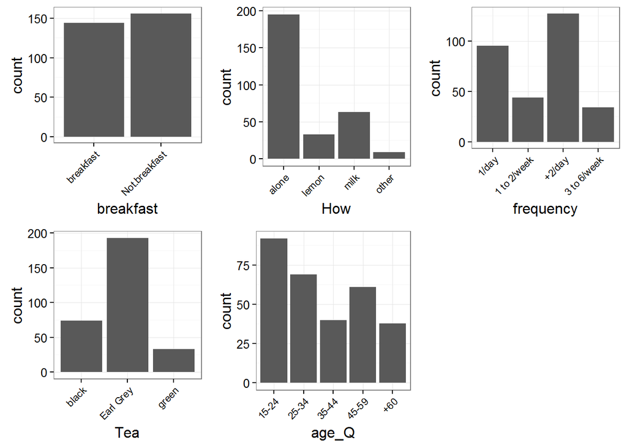

```r
g1 <- ggplot(teatime, aes(breakfast)) + geom_bar() + theme_bw() + theme(axis.text.x = element_text(angle = 45, hjust = 1, size = 8))
g2 <- ggplot(teatime, aes(Tea)) + geom_bar()+ theme_bw() + theme(axis.text.x = element_text(angle = 45, hjust = 1, size = 8))
g3 <- ggplot(teatime, aes(How)) + geom_bar()+ theme_bw() + theme(axis.text.x = element_text(angle = 45, hjust = 1, size = 8))
g4 <- ggplot(teatime, aes(age_Q)) + geom_bar()+ theme_bw() + theme(axis.text.x = element_text(angle = 45, hjust = 1, size = 8))
g5 <- ggplot(teatime, aes(frequency)) + geom_bar()+ theme_bw() + theme(axis.text.x = element_text(angle = 45, hjust = 1, size = 8))

multiplot(g1, g2, g3, g4, g5, cols=3)
```

The most, there are earl grey drinking respondents who drink tea at least twice a day. It seems that about half of the respondents drink tea with breakfast and the other half, on the other hand, does not. If we would take a closer look at the ‘frequency’ variable we should then change the order of the levels because now they do not seem to be logical. However, that is not what we are going to do right now.

Instead, we will now perform a Multiple Correspondence Analysis (MCA) on the new dataset.

```r
mca <- MCA(X = teatime, graph=F)

summary(mca)
```

```
##
## Call:
## MCA(X = teatime, graph = F)
##
##
## Eigenvalues
##                        Dim.1   Dim.2   Dim.3   Dim.4   Dim.5   Dim.6
## Variance               0.317   0.288   0.248   0.231   0.214   0.209
## % of var.             12.205  11.079   9.532   8.870   8.241   8.036
## Cumulative % of var.  12.205  23.285  32.817  41.686  49.927  57.963
##                        Dim.7   Dim.8   Dim.9  Dim.10  Dim.11  Dim.12
## Variance               0.196   0.184   0.177   0.157   0.150   0.125
## % of var.              7.557   7.090   6.801   6.024   5.784   4.811
## Cumulative % of var.  65.520  72.610  79.411  85.435  91.219  96.031
##                       Dim.13
## Variance               0.103
## % of var.              3.969
## Cumulative % of var. 100.000
##
## Individuals (the 10 first)
##                  Dim.1    ctr   cos2    Dim.2    ctr   cos2    Dim.3
## 1             |  0.532  0.297  0.106 |  0.221  0.057  0.018 |  0.025
## 2             |  0.947  0.941  0.321 | -0.164  0.031  0.010 |  0.599
## 3             | -0.066  0.005  0.003 | -0.101  0.012  0.007 | -0.064
## 4             | -0.613  0.394  0.292 | -0.292  0.099  0.066 | -0.154
## 5             |  0.392  0.162  0.103 | -0.492  0.280  0.162 | -0.109
## 6             | -0.613  0.394  0.292 | -0.292  0.099  0.066 | -0.154
## 7             | -0.092  0.009  0.003 |  0.262  0.080  0.021 | -0.455
## 8             |  0.080  0.007  0.002 |  0.876  0.888  0.191 | -0.200
## 9             |  0.721  0.547  0.196 | -0.352  0.143  0.047 | -0.247
## 10            |  0.770  0.623  0.237 |  0.238  0.065  0.023 | -0.454
##                  ctr   cos2
## 1              0.001  0.000 |
## 2              0.483  0.129 |
## 3              0.006  0.003 |
## 4              0.032  0.018 |
## 5              0.016  0.008 |
## 6              0.032  0.018 |
## 7              0.279  0.063 |
## 8              0.054  0.010 |
```

[output cut: 19 more lines]

```
## Earl Grey      -9.415 |  -0.215   2.395   0.083  -4.988 |
## green           2.854 |   1.675  24.904   0.347  10.182 |
## alone          -0.740 |  -0.136   0.969   0.034  -3.202 |
## lemon           1.576 |   0.328   0.956   0.013   1.995 |
## milk           -3.217 |   0.407   2.814   0.044   3.633 |
## other           6.861 |  -1.111   2.990   0.038  -3.379 |
## 15-24          -6.043 |  -0.903  20.174   0.361 -10.383 |
##
## Categorical variables (eta2)
##                 Dim.1 Dim.2 Dim.3
## breakfast     | 0.416 0.275 0.003 |
## Tea           | 0.263 0.307 0.347 |
## How           | 0.303 0.188 0.096 |
## age_Q         | 0.226 0.407 0.485 |
## frequency     | 0.379 0.264 0.309 |
```

The output of MCA gives us Eigenvalues, values for individuals and categories. In the output, at the Categories table there are the v.test values. A v-test value is +/-1.96 if the coordinate in question is significantly different from zero. There are only a few coordinates less than |1.96|, so nearly all of them are significant.

A graphical overview is performed by the MCA factor map below.

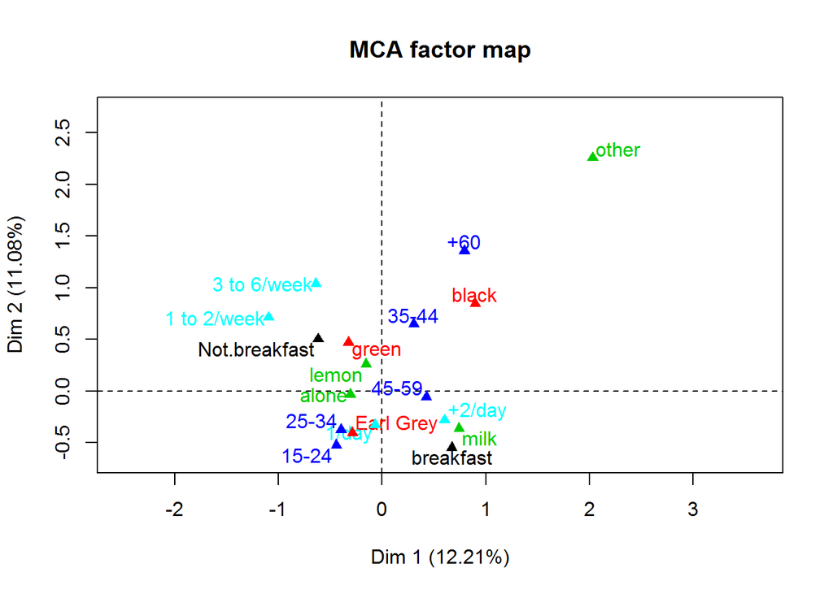

```r
plot(mca, invisible=c("ind"), habillage = "quali")
```

This MCA biplot gives us a good overview of the similarity of the categories on the first two dimensions. The only outstanding category is the ‘other’ value of the variable ‘How’. We find that the categories ‘15-24’ and ‘25-34’ (years) are really close to ‘Earl Grey’ while older age categories are closer to ‘Black’. So maybe the younger respondents prefer earl grey tea to other options. It is also interesting that categories ‘Not.breakfast’ and ‘green’ are close to each other, because this indicates that those not drinking tea for breakfast prefer green tea.